# Degrees and Demand in Virginia

2025-05-05

# Introduction

In today’s rapidly changing workforce, understanding the alignment between educational pathways and job market demand is more important than ever. As a university student, I often find myself questioning if my own degrees will be sufficient to find work in unforeseeable conditions, and if now what degrees are more suitable.

Virginia is currently ranked 13th in the nation for GDP and 7th in post-secondary education attainment. In 2021, the Virginia General Assembly established the Virginia Office of Education Economics (VOEE) to track emerging labor market trends and guide workforce development across the state. According to VOEE, strengthening Virginia’s skilled workforce is essential to sustaining long-term economic resilience and continuing to rise in national economic rankings. In alignment with this goal, the State Council of Higher Education for Virginia (SCHEV) has set a target of achieving a 70% post-secondary degree attainment for Virginia’s workforce by 2030. To reach this milestone, it is crucial to assess whether the degrees being awarded are aligned with the occupations that are projected to be in highest demand.

[figure not shown]

We will analyze the intersection of workforce projections and degree attainment to answer a core question: Are Virginia institutions preparing students for high demand occupations? Through this data exploration, I examine projected job openings in Virginia, the educational requirements for high-demand careers, and how those trends compare to the types of degrees currently being awarded in the state. I will also address the accessibility of various degree paths, considering both cost and duration.

# What Jobs are in High-Demand?

The Virginia Board of Workforce Professions published a spreadsheet of roughly 400 occupations that are in high demand. For simplicity, these careers will be grouped by VOEE career cluster. A career cluster is a collection of jobs within a given industry that share features such as necessary technical skills and academic knowledge.These careers can range from entry-level roles to advanced positions (Academic & Career Plan).

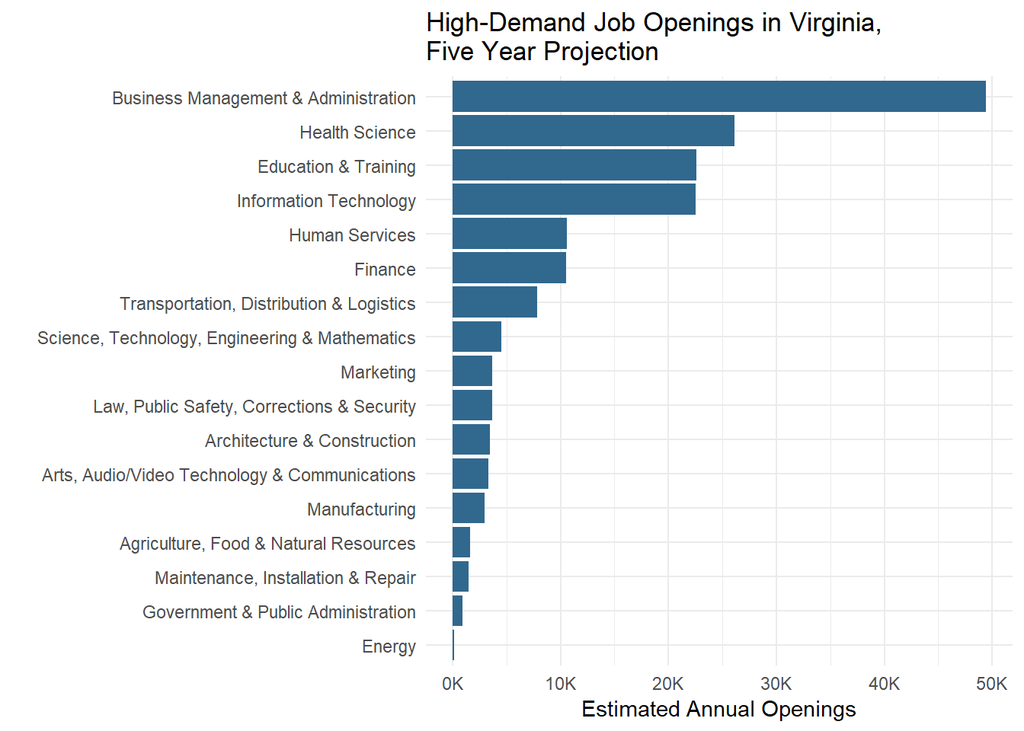

## What are the Expected Incomes for in demand fields and the best degree to have?

Given the best careers that these fields contain, there’s bound to be varying demand and pay associated with each.

[interactive chart not shown]

The first graphic illustrates the relationship between job openings and median income across the previously identified four highest in demand career clusters. The chart is faceted by cluster, highlighting how various jobs within each field compare. The Business Management & Administration cluster stands out, featuring both the highest median incomes and the greatest number of annual job openings. All roles in this cluster require an undergraduate degree—either an associate’s or a bachelor’s.

The second graph shows the relationship between job openings and median income across all job clusters. While there doesn’t appear to be a strong correlation between the number of openings and income, it’s notable that among occupations with a median income above $100,000, only one requires less than a bachelor’s degree. This suggests that to access higher-paying roles in in-demand fields, obtaining at least a bachelor’s degree is often proffered.

# Career Cluster Workforce

Although all careers can be grouped into clusters, there is significant variation in income and required education among individual occupations. This Shiny application provides a visual representation of projected workforce trends across different careers. Users can compare specific occupations within each career cluster, explore projected employment growth, and examine differences in median annual earnings and typical entry-level education requirements.

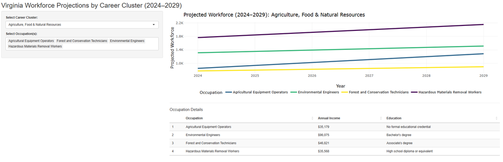

[Open the Shiny App](https://awalk.shinyapps.io/ProjectShiny2/)

# What types of degrees are being awarded?

First, let’s discuss the different degree types.

Certificate programs are short-term, often less than two year programs, and focused on specific skills. They’re typically low-cost and are useful for quickly entering the workforce in trades or technical fields. Because they is no required academic comprehensive study required for certificate obtainment, they are not degrees.

Associate degrees usually take about two years and offer a broader education, in humanities and sciences. They may provide access to careers or be a stepping stone to a four-year degree. Many of the associate degrees offered by the Virginia Community College System (VCCS) serve as the foundation for students to continue education at a four year university.

Bachelor’s degrees take four years, and begin with general humanity and mathematical/science courses before focusing on a specific skill or subject. Though these degrees are more expensive and take the longest to complete they tend to offer the highest long-term income potential.

[interactive chart not shown]

This treemap displays the types of degrees awarded. The size of each rectangle is relative to the number of degrees awarded, with larger rectangles representing higher counts.

Most of the degrees awarded were bachelor’s degrees. Since many high-paying and in-demand jobs list a bachelor’s degree as the minimum entry requirement, this trend reflects both workforce demand and educational individual priorities. It highlights the critical role undergraduate education plays in preparing individuals for competitive careers.

# What is degree breakdown by general category?

From our analysis, we found that occupations within the Business Management & Administration cluster are among the most in demand. Not only is this cluster highly sought after, but it also offers the highest median incomes among the top in-demand fields. Let’s now analyze how different degree types align with these high-demand career clusters.

CIP codes are six digit sequences assigned to certificate and degree programs across the nation’s institutions to equate similar programs at different institutions. These codes are assigned by US Department of Education to track degree trends. Here we group the programs of study by the first two digits of their CIP codes. There are 60 general CIP groupings, from 01 - 60.

For example, all majors within the BUSINESS, MANAGEMENT, MARKETING, AND RELATED SUPPORT SERVICES field begin their CIP with 52. Specific majors within the domain include General Finance (52.0801) and Accounting (52.0301).

[interactive chart not shown]

These bar graphs display the number of degrees awarded in the five general fields of study with the highest degree completion, while all other majors are grouped together. Business, Management, and Marketing, along with Health Professions and Clinical Sciences, are consistently represented across all three degree types. Additionally, Computer and Information Sciences appear among the top fields for both Associates and Bachelor’s degrees.

The representation of Business, Management, and Marketing program areas across degree type aligns with the high demand for occupations within the Business Management & Administration career cluster.

# More Major Specific

There are too many specific majors to list each individually. However, this shiny app will provide a more clear breakdown as to what majors within degree types were awarded by institutions for the 2023-24 academic year. This data is specific to Virginia Higher Learning institutions, but each major is accompanied by its CIP code assigned by the US Department of Education. This app will provide a better understanding of what types of majors are grouped together for the graphics within this analysis and their popularity among post-secondary undergraduate students.

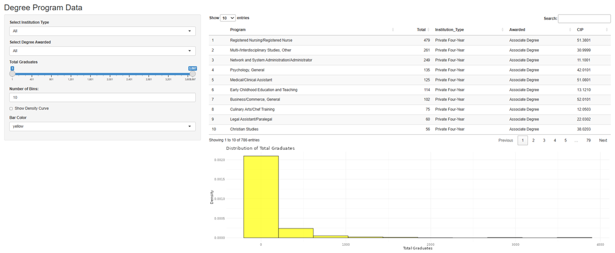

[Open the Shiny App](https://awalk.shinyapps.io/ProjectShiny/)

# How accessible are the degrees?

FastForward (FF) and G3 are Virginia-based tuition assistance programs designed to support students in high-demand career paths. FF focuses on degrees forcused on skill and perfomance training for in-demand jobs , helping cover most of the tuition at community colleges and vocational schools. G3 goes a little further, offering full financial aid (including tuition, books, and other essentials) to qualifying low and middle-income students pursuing degrees or certificates in critical fields. Together, these programs aim to make career-focused education more accessible and affordable to Virginians.

College can be a powerful driver of economic mobility, the ability to improve economic standing, especially for students from low-income backgrounds. While not a guaranteed ticket to prosperity, a college degree significantly increases the chances of moving up the income ladder. As shown, there is a correlation between degree and income, with occupations with higher median income often requiring a bachelor’s degrees for entry position.

The next three plots will analyze how expected income differs between career pathways with funding and those without.

[interactive chart not shown]

The boxplots show no clear trend between expected income and funding availability. In all graphs, the income distributions for individuals with and without funding have similar medians, within approximately $10,000 of each other. This suggests that high-paying occupations are accessible to individuals regardless of funding status. The degrees with solely G3 Funding have the highest median income.

## Conclusion

We have explored the in-demand careers of Virginia and analyzed the state’s degree obtainment. As of the 2023-2024 academic school year, degrees align with the highest and demand jobs. There’s also great accessibility to education needed to enter respective fields regardless of economic background. Virginia institutions are preparing students for high demand occupations.